## Controlando elementos do tema

Vários elementos do tema podem ser controlados a partir de funções específicas associadas à função `theme()`.

A família de funções `element_` especificam a exibição de como os componentes sem dados do gráfico são desenhados.

*`element_blank`: não desenha nada e não atribui espaço;

*`element_rect`: bordas e fundos;

*`element_line`: linhas;

*`element_text`: texto;

*`rel()` é usado para especificar os tamanhos relativos ao objeto original;

*`margin()` é usado para especificar as margens dos elementos.

Por exemplo, vamos duplicar o tamanho de fonte (`rel(2)`) do título do gráfico já criado `meu_plot`.

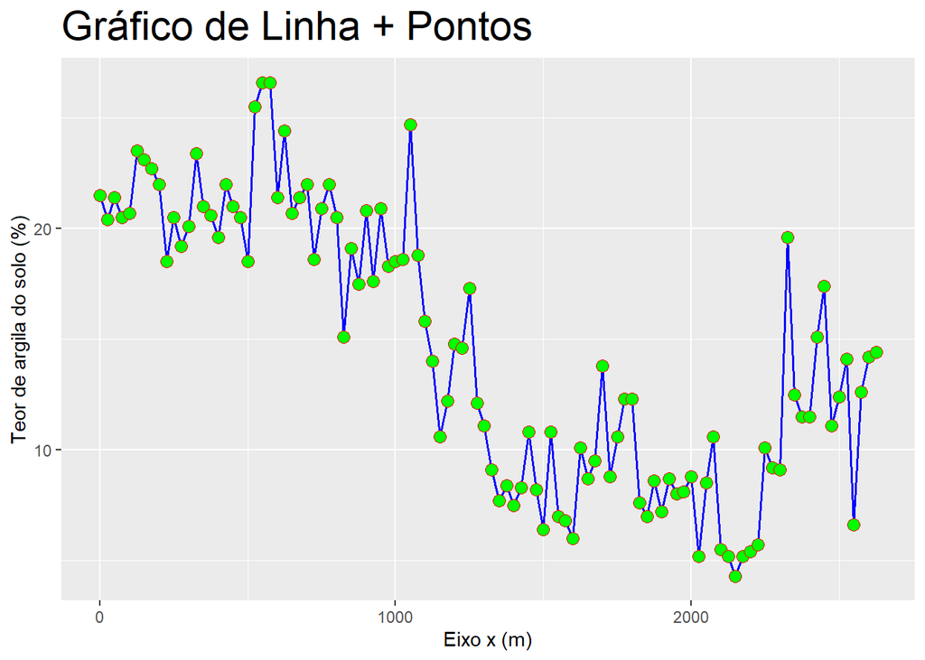

```r
meu_plot + theme(plot.title = element_text(size=rel(2)))
```

Vamos modificar o alinhamento do e a cor do título do gráfico já criado `meu_plot`.

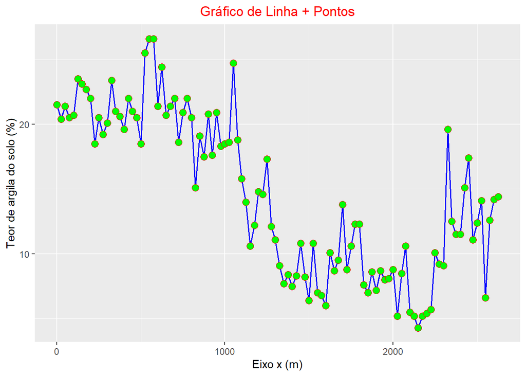

```r
meu_plot + theme(plot.title = element_text(hjust = 0.5, color = "red"))
```

Alterando a área de plotagem.

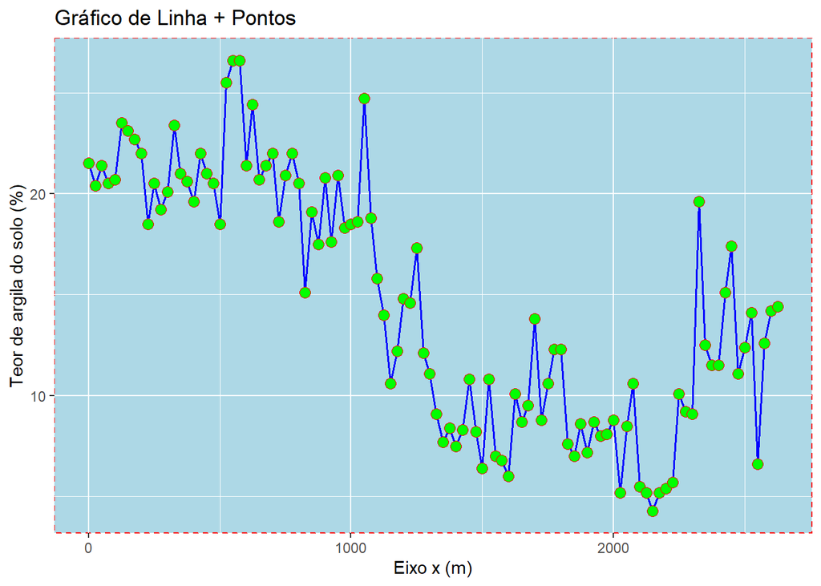

```r
meu_plot + theme(panel.background = element_rect(fill="lightblue", color = "red", linetype = "dashed"))
```

Agora vamos fazer várias modificações, adicionando linhas de grade na área de plotagem, mudar as cores do texto dos eixos para vermelho, as cores dos títulos dos eixos para verde escuro e alterar a cor do retângulo de plotagem exterior para cinza.

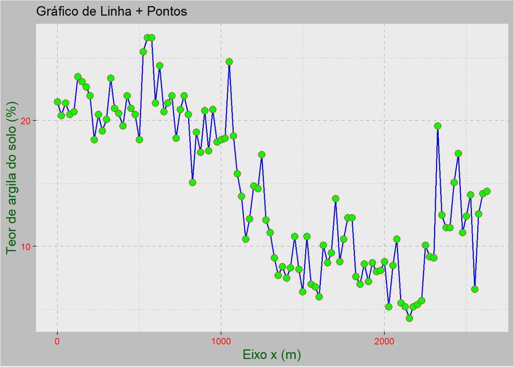

```r
meu_plot + theme(panel.grid.major = element_line(color="gray", linetype = "dashed"),
                 panel.grid.minor = element_line(color="gray", linetype = "dashed"),
                 axis.text = element_text(colour = "red"),
                 axis.title = element_text(colour = "darkgreen",size=rel(1.2)),
                 plot.background = element_rect(fill="gray"))
```

Maiores informações a respeito dos parâmetros de controle dos elementos dos gráficos podem ser encontrados em https://ggplot2.tidyverse.org/reference/theme.html.

## Mapeamento estéticos

Vamos voltar ao gráfico de dispersão do teor de argila do solo ao longo do transecto estudado.

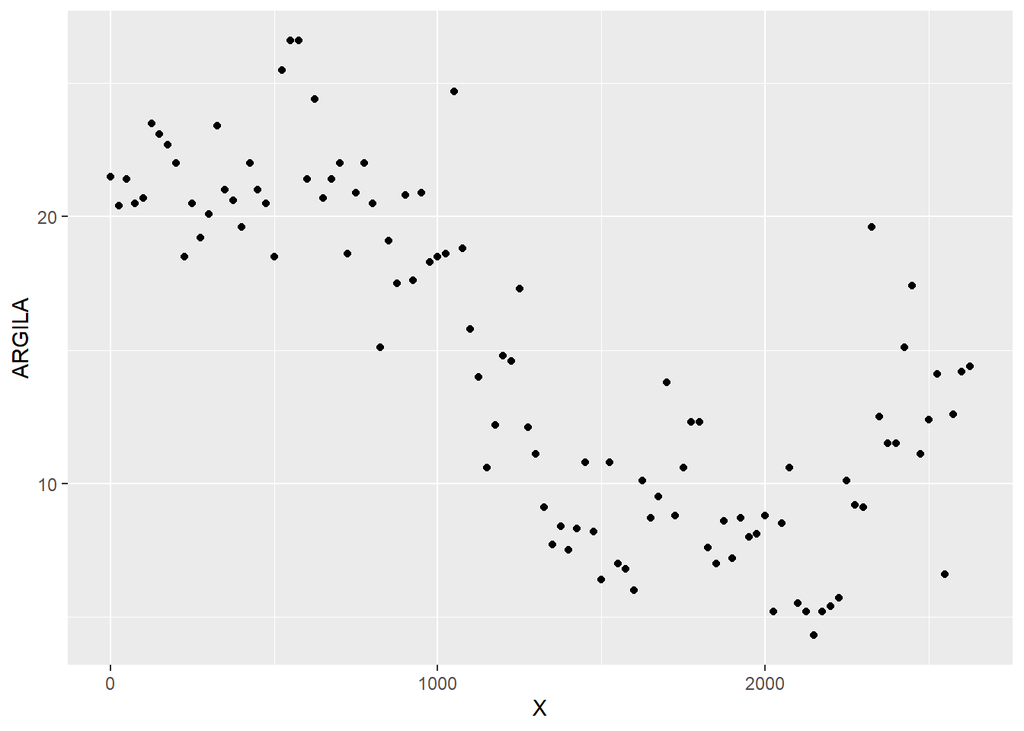

```r
geomorfologia %>%
  ggplot( aes(x=X, y =ARGILA) ) +
  geom_point()
```

Podemos agora adicionar uma terceira variável a esse gráfico, como tipo de solo (`Solo`) ou a superfície geomórfica (`SUP`), e mapeá-la a partir de um **estético** *(aesthetic)*. Esse estético é uma propriedade visual dos objetos no gráfico. Estéticos incluem coisas como tamanho, forma ou cor dos pontos.

Em nosso exemplo inicial Vamos mapear as cores dos pontos para cada superfície geomórfica (`SUP`).

Para mapear a estética *cor* à variável `SUP`, devemos associar o nome da estética ao nome da variável dentro de `aes()`. O `ggplot2` atribuirá automaticamente uma cor singular para cada valor singular da variável, um processo conhecido como **escalar** (*scaling*). Automaticamente será adicionado uma legenda que explica quais níveis correspondem a quais valores.

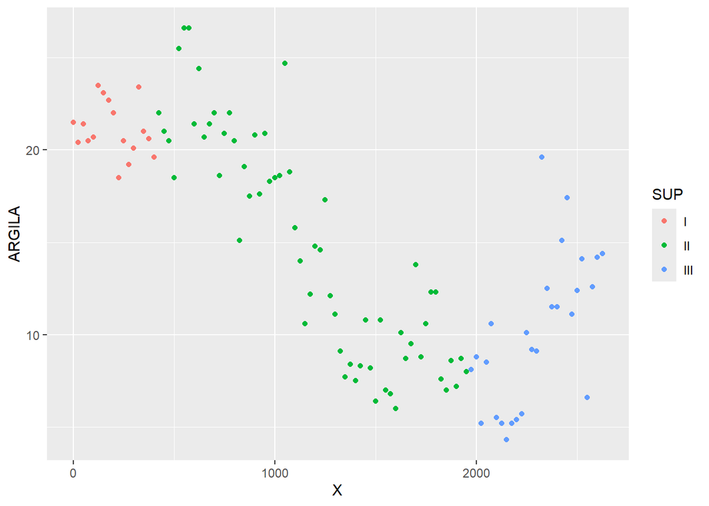

```r
geomorfologia %>%
  ggplot( aes(x=X, y =ARGILA, col = SUP) ) +
  geom_point()
```

No exemplo anterior mapeamos `SUP` à estética *cor*, mas poderíamos ter mapeado `SUP` à estética de *tamanho* (`size`) da mesma maneira.

Neste caso, o tamanho exato de cada ponto revela a sua superfície. Entretanto, não recomendamos o mapeamento de uma variável por meio do tamanho.

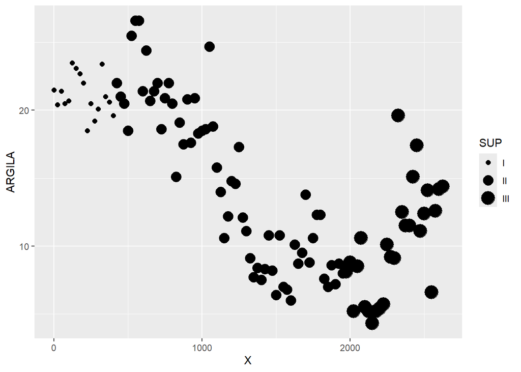

```r
geomorfologia %>%
  ggplot( aes(x=X, y =ARGILA, size = SUP) ) +
  geom_point()
```

Poderíamos ter mapeado `SUP` à estética `alpha`, que controla a transparência e à forma dos pontos controlada pelas estética `shape`.

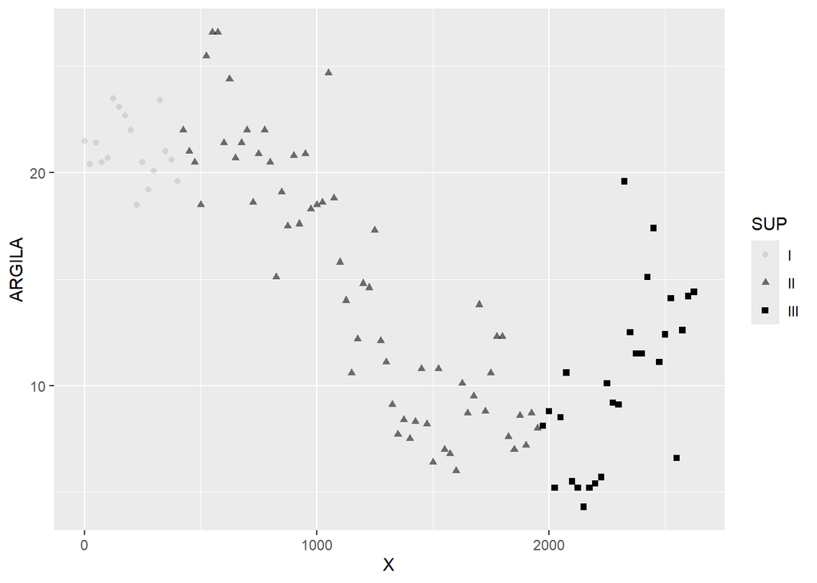

```r
geomorfologia %>%
  ggplot( aes(x=X, y =ARGILA, alpha = SUP, shape=SUP) ) +
  geom_point()
```

## Facetas

As facetas são consideradas uma maneira prática de adicionar mais variáveis categóricas às representações gráficas.

Para criar facetas use a função `facet_wrap()`, cujo primeiro argumento deve ser uma fórmula (definida com `~` e o nome da variável categórica subsequente) e o segundo argumento é o número de linhas do painel gráfico.

Compare os painéis abaixo:

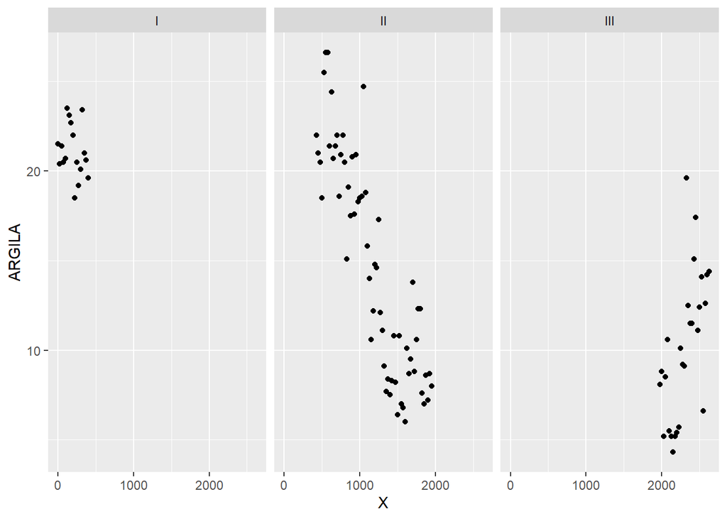

```r
geomorfologia %>%
  ggplot( aes(x=X, y =ARGILA) ) +
  geom_point() +
  facet_wrap(~SUP, nrow=1)
```

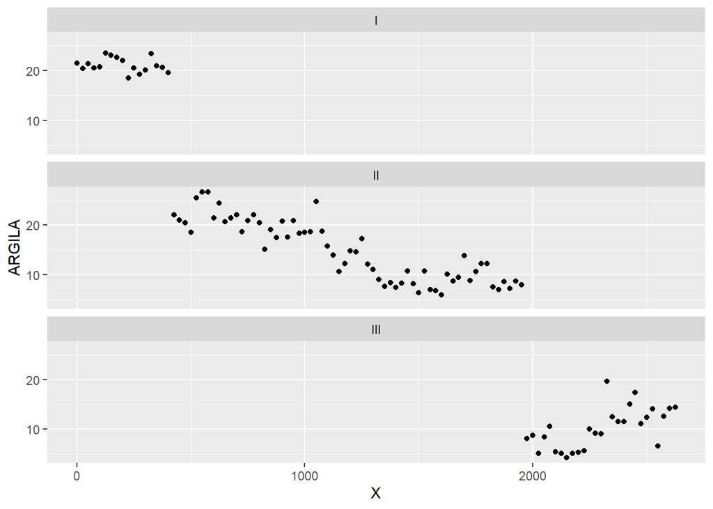

```r
geomorfologia %>%
  ggplot( aes(x=X, y =ARGILA) ) +
  geom_point() +
  facet_wrap(~SUP, nrow=3)
```

Outra importante e útil ferramenta é a função `facet_grid` que permite a incorporação de mais de uma variável na representação, no nosso exemplo, vamos adicionar o tipo de solo `Solo`. A fórmula conterá dois nomes de variáveis categóricas sepradas pelo `~`

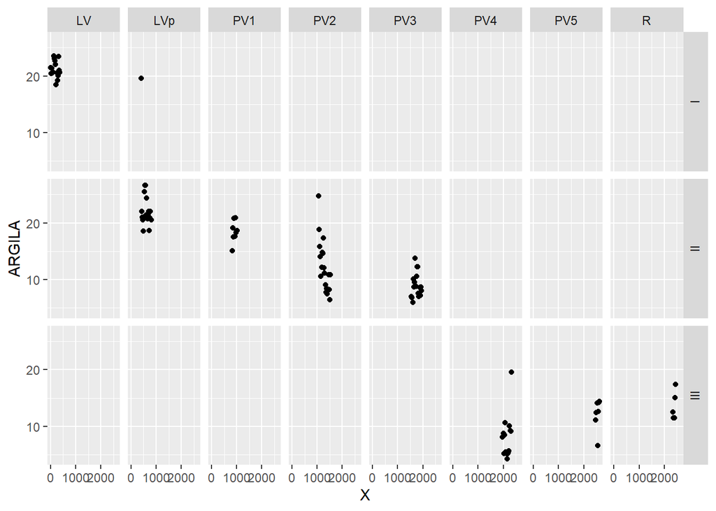

```r
geomorfologia %>%
  ggplot( aes(x=X, y =ARGILA) ) +
  geom_point() +
  facet_grid(SUP ~ Solo)
```

Agora podemos mesclar as visualisações, utilizando o mapeamento estético e as facetas.

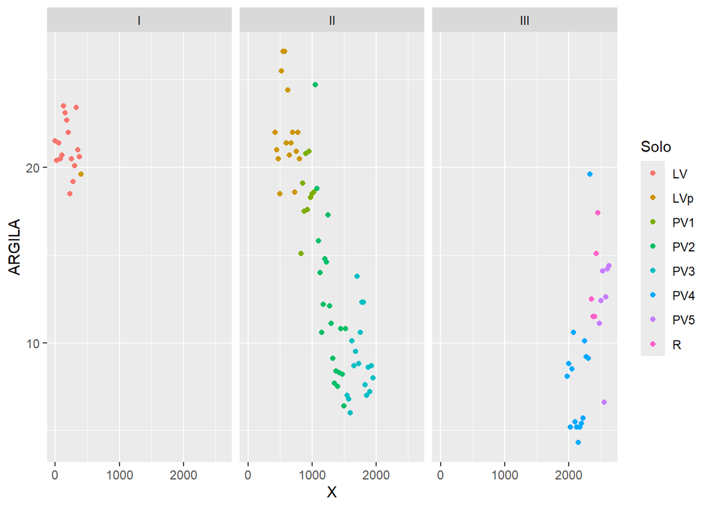

```r
geomorfologia %>%
  ggplot( aes(x=X, y =ARGILA, color=Solo) ) +
  geom_point() +
  facet_wrap(~SUP, nrow=1)
```

ou,

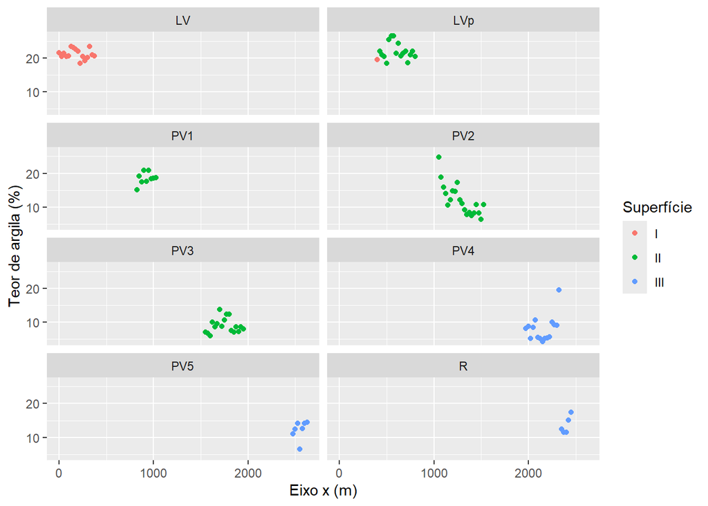

```r
geomorfologia %>%
  ggplot( aes(x=X, y =ARGILA, color=SUP) ) +
  geom_point() +
  facet_wrap(~Solo, nrow=4) +
  labs(x="Eixo x (m)", y= "Teor de argila (%)", color="Superfície")
```

## Objetos geométricos

### Gráfico de Colunas

Um `geom_` é o objeto geométrico que um gráfico usa para representar os dados. Gráficos de colunas, por exemplo, usam o `geom_col()`. O preenchimento e as cores das bordas das colunas são controlados pelos argumentos `fill` e `color`. Gráfico de coluas, linhas e pontos, plotam os valores brutos.

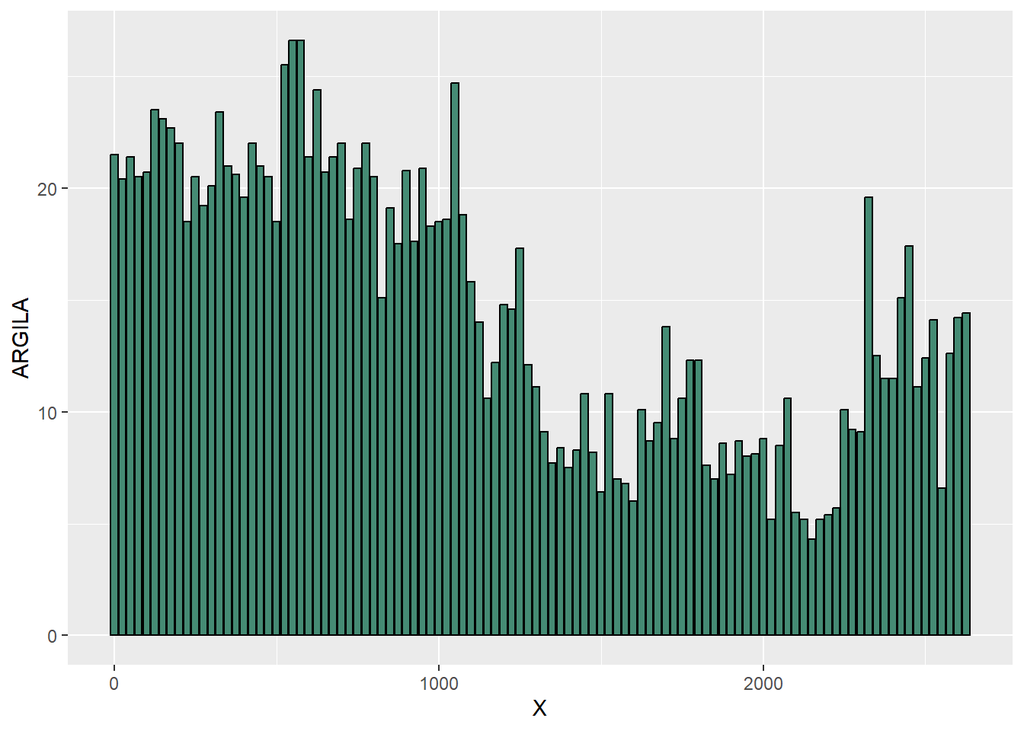

```r
geomorfologia %>%
  ggplot( aes(x=X, y =ARGILA) ) +
  geom_col(color="black",fill="aquamarine4")
```

O gráfico de **colunas** também pode ser apresentadorotacionado em 90º a partir do uso da função`coord_flip()`.

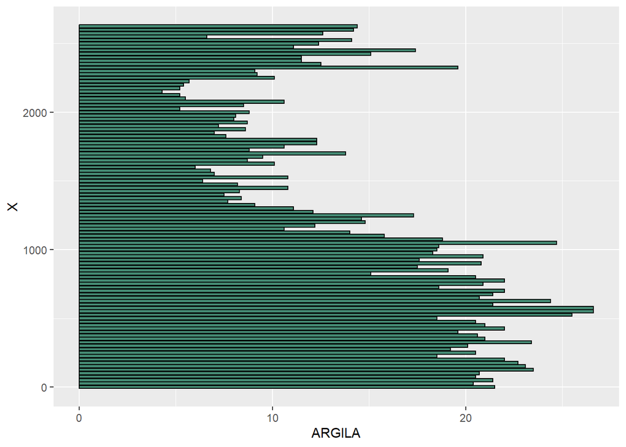

```r
geomorfologia %>%
  ggplot( aes(x=X, y=ARGILA) ) +
  geom_col(color="black",fill="aquamarine4") +
  coord_flip()
```